# 34263594_Assign_2

The remainder shows peaks around 2010 and trough in 2020 which deviate from it fluctuating around 0. According to the ABS, real net disposable income grew by 6.3% during 2010-2011 which could be a reason for this spike (ABS, October 2011, Australian System of National Accounts, 2010-2011, [https://www.abs.gov.au/ausstats/abs@.nsf/Previousproducts/5204.0Main%20Features22010-11?opendocument&tabname=Summary&prodno=5204.0&issue=2010-11&num=&view=# ], ABS website, accessed 22nd March 2022). The trough in 2020 may be attributed to COVID19

```r
retail |> model(STL(log(Turnover)))|> components() |> gg_season()
```

```
## Plot variable not specified, automatically selected `y = log(Turnover)`
```

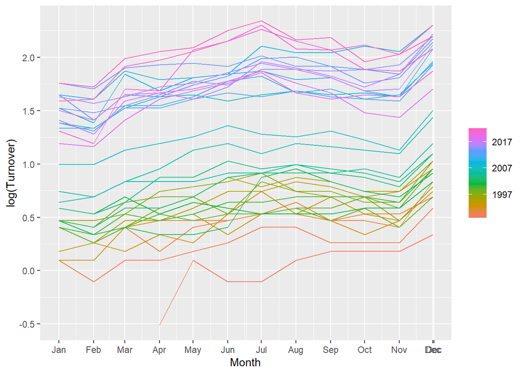

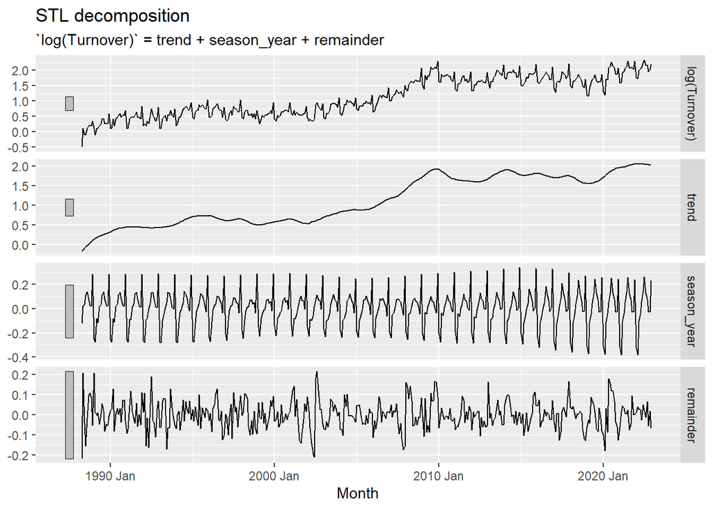

```r
retail |> model(STL(log(Turnover)))|> components() |> autoplot()
```

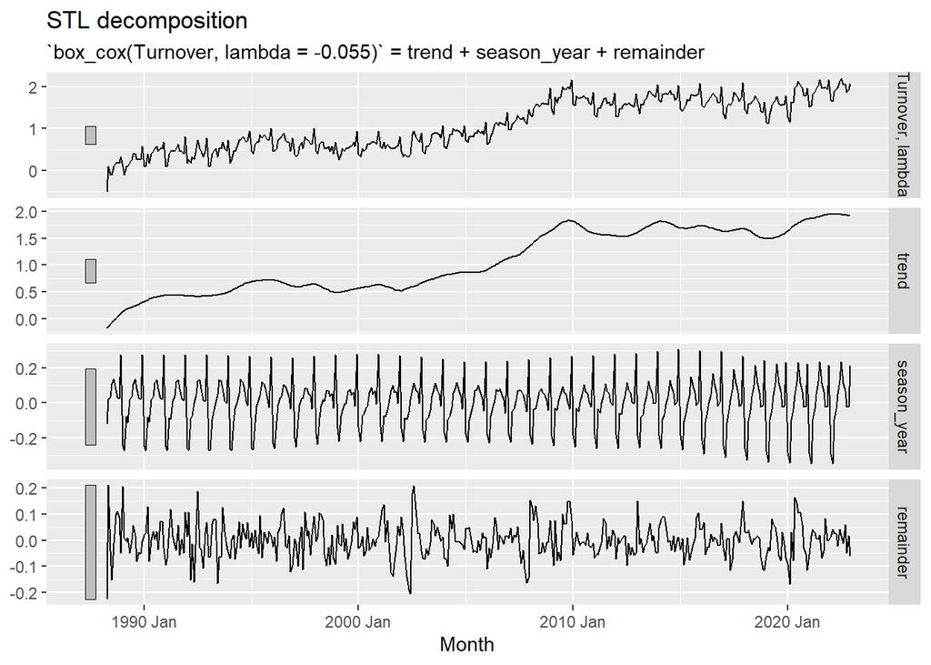

```r
retail |> model(STL(box_cox(Turnover, lambda=-0.055)))|> components() |> autoplot()
```

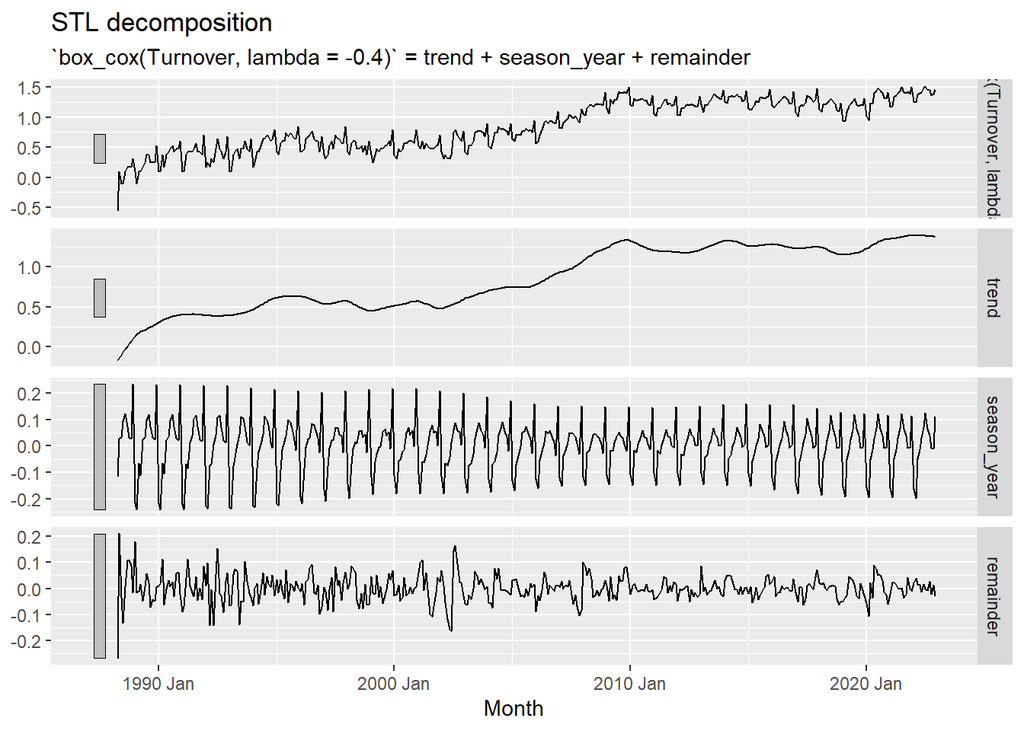

```r
retail |> model(STL(box_cox(Turnover, lambda=-0.4)))|> components() |> autoplot()
```

Transformation and Differencing